# MiniProyecto

Sergio Marín Castro // Laura Isabel Montoliu Peris // Beatriz Perello Osborne // Gonzalo Sanchez Muñoz

11/4/2022

```r
knitr::opts_chunk$set(echo = TRUE)

# cargamos las librerías necesarias

library(readr)
library(dplyr)
library(tidyr)
library(stringr)
library(lubridate)
```

```r
library(ggplot2)
library(paletteer)
library(plotly)
library(GGally)
library(kableExtra)
library(gganimate)
library(gifski)
```

##**Descarga de ficheros de datos**

Descargamos los ficheros de datos con la información sobre las calles de Ruzafa, y los almacenamos en una carpeta local $./data$.

SIGNIFICADO DE LAS VARIABLES

recvTime : Fecha en la que se insertó el dato en la plataforma .

FiwareServicePath : Servicio al que pertenece el sensor.

EntityType : Tipo de sensor.

EntityId : Identificador único del sensor.

LAeq : En este caso el período establecida para este sensor es de 1 minuto.

LAeq_d: Es un indicador de ruido durante el día desde las 7 hasta las 19 horas.(12h) LAeq_den: Índice de ruido día-tarde-noche, para determinar la molestia vinculada a la exposición al ruido.

LAeq_e: Es un indicador del nivel sonoro durante la tarde desde las 19 hasta las 23 horas.(4h).

LAeq_n: Es un indicador del nivel sonoro durante la noche desde las 23 hasta las 7 horas.(8h).

Dateobserved: Día al que se refieren las medidas.

##**Importar y fusionar los datos en un solo dataframe**

Este paso consiste en importar y fusionar todos los datos en un solo dataframe (“RUZAFA”), además debemos realizar una exploración inicial de los datos.

Para ello, vamos a importar todos los ficheros de datos descargados anteriormente, creando una variable con el dataframe de dichos ficheros.

```r
# Importamos ficheros en data frames
VivChafCadz <- read_csv("data/ VivonsChaflánCádiz.csv", show_col_types = FALSE)
Cadiz3 <- read_csv("data/Cadiz3.csv", show_col_types = FALSE)
Cadiz16 <- read_csv("data/Cadiz16.csv", show_col_types = FALSE)
CarlCerv34 <- read_csv("data/CarlesCervera34.csv", show_col_types = FALSE)
CarlCervChaf <- read_csv("data/CarlesCervera Chaflán.csv", show_col_types = FALSE)
Cuba3 <- read_csv("data/Cuba3.csv", show_col_types = FALSE)
DoctorSerrano21 <- read_csv("data/DoctorSerrano21.csv", show_col_types = FALSE)
GeneralPrim <- read_csv("data/GeneralPrim.csv", show_col_types = FALSE)
PuertoRico21 <- read_csv("data/PuertoRico21.csv", show_col_types = FALSE)
SalvAbrilChaf <- read_csv("data/SalvadorAbrilChaflán.csv", show_col_types = FALSE)
Sueca2 <- read_csv("data/Sueca2.csv", show_col_types = FALSE)
Sueca32 <- read_csv("data/Sueca32.csv", show_col_types = FALSE)
Sueca61 <- read_csv("data/Sueca61.csv", show_col_types = FALSE)
SuecaEsqDenia <- read_csv("data/SuecaEsqDenia.csv", show_col_types = FALSE)
```

Para una clara exploración debemos unir los data frames, creando así uno más grande con toda la información, en este caso ‘RUZAFA’.

```r
# unimos los data frames
RUZAFA <- VivChafCadz %>%
  full_join(Cadiz3) %>%
  full_join(Cadiz16) %>%
  full_join(CarlCervChaf) %>%
  full_join(CarlCerv34) %>%
  full_join(Cuba3) %>%
  full_join(DoctorSerrano21) %>%
  full_join(GeneralPrim)  %>%
  full_join(PuertoRico21) %>%
  full_join(SalvAbrilChaf)%>%
  full_join(Sueca2 )%>%
  full_join(Sueca32) %>%
  full_join(Sueca61) %>%
  full_join(SuecaEsqDenia)
#View(RUZAFA)
```

##**Exploración inicial**

Vamos a realizar la primera exploración inicial. Para ello vamos a ver sus dimensiones, nombres de variables, mayor y menor fecha observada, resumen de los datos numéricos…

```r
#Dimension de df, nombre de variables, max y min fecha cantidad de distintos tipos de variables

dim(RUZAFA)
names(RUZAFA)

attach(RUZAFA)

max(dateObserved) # última fecha
min(dateObserved) # primera fecha

table(entityType)
table(fiwareServicePath)
table(entityId)

detach(RUZAFA)
```

Mediante estas funciones hemos observado varias cosas a destacar sobre la información:

**DIMENSIONES RUZAFA** –> - Columnas = 11 - Filas = 6450

NOMBRES VARIABLES DE RUZAFA : (id, recvTime,fiwareServicePath,entityType,entityI,LAeq,LAeq_d,LAeq_den,LAeq_e,LAeq_n, dateObserved)

MáXIMA FECHA OBSERVADA: 2022-04-10 MíNIMA FECHA OBSERVADA: 2020-09-17

**DATOS DISPONIBLES DE CADA CALLE** –>

T248652-daily: 469 T248655-daily: 476 T248661-daily: 483 T248669-daily: 488 T248670-daily: 464 T248671-daily: 475 T248672-daily: 465 T248676-daily: 460 T248677-daily: 476 T248678-daily: 487 T248680-daily: 454 T248682-daily: 447 T248683-daily: 327 T248684-daily: 479

**DISTINTOS TIPOS DE SENSOR :** 1 DISTINTOS TIPOS DE SERVIVIOS A LOS QUE PERTENECEN LOS SENSORES: 1

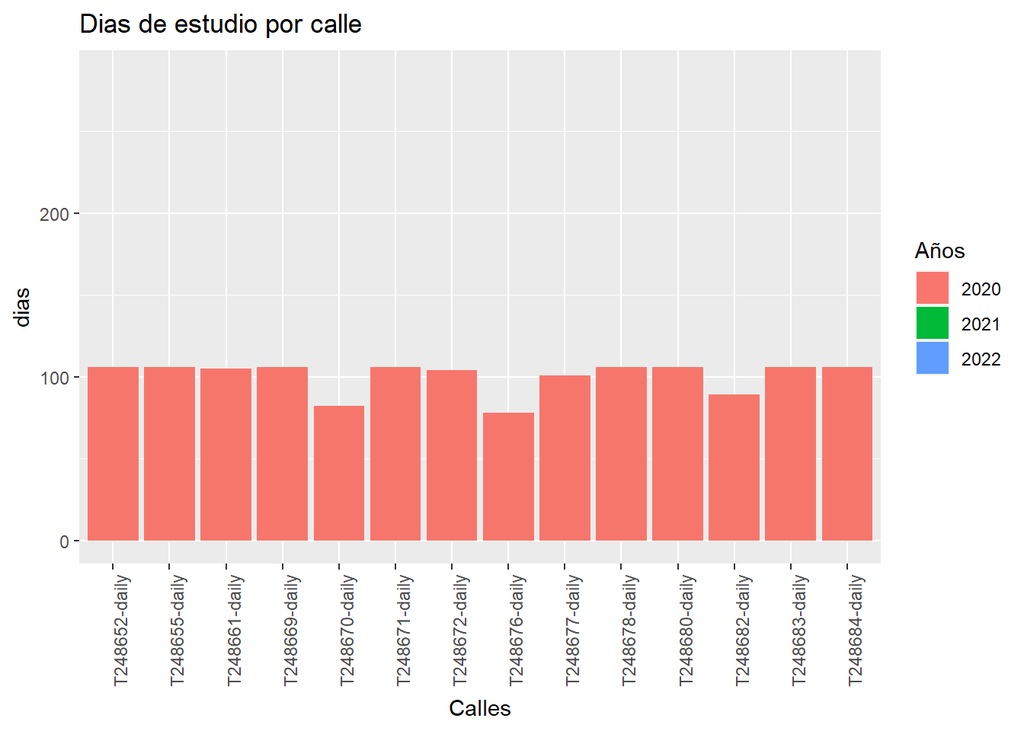

```r
ggplot(RUZAFA, aes(entityId, fill =factor(year(dateObserved)))) + geom_bar() +theme(axis.text.x = element_text(angle = 90, hjust = 1))+labs(x="Calles",y = "dias", title="Dias de estudio por calle") + guides(fill = guide_legend(title = "Años"))+transition_states(year(dateObserved))
```

Gracias al gráfico vemos que en una calle de las registradas no hay información sobre el año 2022. Y que no todas las calles tienen el mismo número de datos para el año 2020 y 2021, sin embargo para 2022 sí.

```r
#Analizamos si los años estan completos o a alguno le falta algún dato.
COMPLT = RUZAFA%>%
  group_by(Año = year(dateObserved))%>%
  summarise(min= min(dateObserved) ,max = max(dateObserved))


COMPLT %>%
  kbl() %>%
  kable_styling(bootstrap_options = "striped", full_width = F)
```

| Año | min | max |
| --- | --- | --- |
| 2020 | 2020-09-17 | 2020-12-31 |
| 2021 | 2021-01-01 | 2021-12-29 |
| 2022 | 2022-01-04 | 2022-04-10 |

```r
#Hacemos una tabla con el resumen de las variables numéricas.
RUZAFA1= pivot_wider(RUZAFA)
RUZAFA1 = RUZAFA1 %>% select(starts_with("LA"))

summary = summary(RUZAFA1)
SUMMARY = data.frame(summary)
SUMMARY = SUMMARY %>% separate(Freq, into = c("Medida", "Valor"), sep= ":")
SUMMARY = pivot_wider(SUMMARY, names_from = Medida, values_from = Valor)
SUMMARY = SUMMARY %>% select(-Var1)

SUMMARY %>%
  kbl() %>%
  kable_material(c("striped", "hover"))
```

| Var2 | Min. | 1st Qu. | Median | Mean | 3rd Qu. | Max. |
| --- | --- | --- | --- | --- | --- | --- |
| LAeq | 49.60 | 58.50 | 60.40 | 60.78 | 62.10 | 91.30 |
| LAeq_d | 51.3 | 59.6 | 61.7 | Inf | 63.4 | Inf |
| LAeq_den | 52.60 | 61.40 | 63.40 | 63.99 | 65.80 | 96.40 |
| LAeq_e | 46.3 | 57.8 | 60.1 | Inf | 63.2 | Inf |
| LAeq_n | 40.1 | 51.3 | 54.0 | 54.7 | 57.5 | 90.0 |

LLama la atención que en algunos valores pone “Inf”, esto es debido a que aún no hemos “limpiado” nuestros datos, por tanto,hay valores incorrectos que deben de ser sustituidos.

Con los datos que tenemos parece ser que el menor nivel sonoro registrado fue por la noche y el mayor durante el día,tarde y noche. Y haciendo las medias de cada nivel sonoro parece que los mayores niveles los ha registrado el sensor de día, tarde, noche, pero no podemos estar seguros hasta que no limpiemos nuestros datos.

Planteamos preguntas a resolver:

HILO DE LA PRESENTACION–> Un grupo de estudiantes acaban de llegar a Valencia y buscan un barrio tranquilo para poder estudiar sin que le molesten los vecinos. Les han comentado que el de Ruzafa es uno de los más tranquilos. Por ello, nos han pedido que estudiemos acerca de la contaminación acústica en este barrio.

-Exploración inicial - Datos faltantes

1.¿Cuál es la calle que más ha molestado a los vecinos en en los tres últimos años?¿Y la que menos?. *2.¿Qué calle ha incrementado más el ruido a lo largo del año 2022?. 3.¿La sonoridad en Ruzafa ha ido aumentado o disminuyendo a lo largo del tiempo?.¿El covid afectó en algo? ¿Y las fallas? ¿Y la Navidad?.* 4.¿Qué calles han sido las más ruidosas durante el día, la tarde, y la noche? ¿Y las que menos?. 5.¿Suele haber más silencio por la tarde, noche o durante el día en Ruzafa? 6.¿Cuál es la calle que más molestó a los vecinos sin contar los meses de verano? ¿Y la que menos?. 7.¿Qué calles son las más tranquilas para vivir en cada estación del año?. 8.¿En qué día de la semana ha habido más ruido por calle?¿Y en general?.

- Análisis univariante
- Análisis bivariante

##**Tidy Dataset**

Para obtener un tidy dataset, es decir, un dataframe más representativo y claro, vamos a modificar los nombres de las columnas por unos más adecuados.

Además de modificar los nombres de las columnas vamos a realizar ciertas operaciones para dejar un tidy dataset, como por ejemplo, eliminar las columnas que no son de utilidad, para ello nos asegurarnos de que hay 1 única variable por columna, eliminar o sustituir datos faltantes o datos incorrectos…

Primero comenzamos modificando el nombre de las columnas, mirando los nombres que tiene nuestro data frame.

```r
#colnames(RUZAFA) # miramos los nombres que tiene el data frame
colnames(RUZAFA) <- c("Id", "Fecha_Registro", "Servicio_Sensor", "Tipo_Entidad_Sensor", "Id_Sensor",
                      "Nivel_Sonoro_Continuo", "Nivel_Sonoro_Dia", "Nivel_Sonoro_dtn",
                      # dtn - día, tarde y noche
                      "Nivel_Sonoro_Tarde", "Nivel_Sonoro_Noche", "Dia_Medicion", "Nombre_Calle")
```

A continuación eliminaremos las columnas que no nos interesen. En este caso los niveles sonoros están en varias columnas pero para que sea un conjunto tidy debe de haber una variable por cada columna.

```r
RUZAFA1 <- RUZAFA %>% select(-Servicio_Sensor, -Tipo_Entidad_Sensor)
RUZAFA_TIDY2 <- RUZAFA1 %>% gather(Nivel_Sonoro, Valores, 4:8)
```

Observamos si hay si hay datos faltantes o incorrectos para sustituirlos. Como hemos visto, hay dos valores “Inf” que los sustituiremos por los valores más frecuentes(media).

```r
breaks <- c(min(RUZAFA_TIDY2$Valores), 0, 5, max(RUZAFA_TIDY2$Valores))

#Calculamos la media para sustituirla por los datos Inf(Media 60.4) y convertimos la columna Nivel_Sonoro en factores.

M  = RUZAFA_TIDY2 %>% filter(Valores != "Inf") %>% summarise(Media = mean(Valores))

RUZAFA_TIDY <- RUZAFA_TIDY2 %>%
  mutate(Valores = ifelse(Valores ==  "Inf", 60.4, Valores)) %>%
  mutate(Nivel_Sonoro = as.factor(Nivel_Sonoro))
```

Por último separamos la columna Fecha Registro, ya que tiene dos variables una de fecha y otra de tiempo y convertimos la columna fecha en una variable de tipo date.

```r
RUZAFA_TIDY = RUZAFA_TIDY %>%
              separate(Fecha_Registro, into=c("Fecha_Registro","Hora_Registro"), sep=10) %>% mutate(Fecha_Registro = as.Date(Fecha_Registro))
```

Aunque no es tidy, también añadimos la columna calles para que sea más fácil de entender los resultados. Entonces, seleccionamos la columna de Id_sensor.

```r
Id_Sensor = RUZAFA_TIDY %>% select(Id_Sensor)
```

El siguiente paso será crear una columna para las Calles e introducirla en nuestro dataframe.

```r
RUZAFA_TIDY = RUZAFA_TIDY %>%
  mutate(Id_Sensor = ifelse(Id_Sensor == "T248655-daily", "Cadiz3 ", Id_Sensor))%>%
  mutate(Id_Sensor = ifelse(Id_Sensor == "T248677-daily" , "VivChafCadz", Id_Sensor))%>%
  mutate(Id_Sensor = ifelse(Id_Sensor == "T248671-daily" , " Cadiz16 ", Id_Sensor))%>%
  mutate(Id_Sensor = ifelse(Id_Sensor == "T248670-daily" , "CarlCervChaf", Id_Sensor))%>%
  mutate(Id_Sensor = ifelse(Id_Sensor == "T248678-daily" , "CarlCerv34 ", Id_Sensor)) %>%
  mutate(Id_Sensor = ifelse(Id_Sensor == "T248682-daily" , "Cuba3", Id_Sensor)) %>%
  mutate(Id_Sensor = ifelse(Id_Sensor == "T248669-daily" , "DoctorSerrano21", Id_Sensor))%>%
  mutate(Id_Sensor = ifelse(Id_Sensor == "T248682-daily" , "Cuba3", Id_Sensor)) %>%
  mutate(Id_Sensor = ifelse(Id_Sensor == "T248672-daily" , "PuertoRico21", Id_Sensor))%>%
  mutate(Id_Sensor = ifelse(Id_Sensor == "T248676-daily" , "SalvAbrilChaf", Id_Sensor))%>%
  mutate(Id_Sensor = ifelse(Id_Sensor == "T248683-daily", "Sueca2" , Id_Sensor))%>%
  mutate(Id_Sensor = ifelse(Id_Sensor == "T248680-daily" , "Sueca32", Id_Sensor))%>%
  mutate(Id_Sensor = ifelse(Id_Sensor == "T248684-daily","Sueca61", Id_Sensor))%>%
  mutate(Id_Sensor = ifelse(Id_Sensor == "T248652-daily","SuecaEsqDenia",  Id_Sensor))%>%
  mutate(Id_Sensor = ifelse(Id_Sensor == "T248661-daily" , "GeneralPrim",  Id_Sensor))

#Cambiamos de nuevo el nombre de las variables:
colnames(RUZAFA_TIDY) <- c("Id", "Fecha_Registro", "Hora_Registro", "Calles", "Dia_Medicion", "Nivel_Sonoro", "Valores")
```

Unimos el dataframe con las calles y con Id_Sensores.

```r
RUZAFA_TIDY = cbind(RUZAFA_TIDY, Id_Sensor)
```

Y por último, ordenamos de nuevo las columnas.

```r
RUZAFA_TIDY = RUZAFA_TIDY [ , c(1,8,2,3,4,6,7,5)]
```

##**ANÁLISIS DE DATOS**

Ahora vamos a hacer un análisis profundo de los datos para responder a las preguntas planteadas.

## **Pregunta 1**

**¿Cuál es la calle que más ha molestado a los vecinos en en los tres ultimos años?¿Y la que menos?**

· *LA QUE MÁS:*

Primero de todo, seleccionamos la calle con más ruido de cada año:

```r
Año2020 = RUZAFA_TIDY %>% group_by(Calles) %>% filter(year(Dia_Medicion) == "2020" & Nivel_Sonoro == "Nivel_Sonoro_Continuo") %>% summarise(MaxRuido = mean(Valores)) %>% filter(MaxRuido == max(MaxRuido))

Año2021 = RUZAFA_TIDY %>% group_by(Calles) %>% filter(year(Dia_Medicion) == "2021"& Nivel_Sonoro == "Nivel_Sonoro_Continuo") %>% summarise(MaxRuido = mean(Valores)) %>% filter(MaxRuido == max(MaxRuido))

Año2022 =  RUZAFA_TIDY %>% group_by(Calles) %>% filter(year(Dia_Medicion) == "2022"& Nivel_Sonoro == "Nivel_Sonoro_Continuo") %>% summarise(MaxRuido = mean(Valores)) %>% filter(MaxRuido == max(MaxRuido))
```

Los unimos y creamos un nuevo data frame para luego añadirle la columna de años convertida en Factor.

```r
MaxMolestia = rbind(Año2020, Año2021, Año2022)

MaxMolestia = MaxMolestia %>% mutate(Año = c(2020, 2021, 2022)) %>% mutate(Año = as.factor(Año))

MaxMolestia %>%
  kbl() %>%
  kable_styling(bootstrap_options = "striped", full_width = F)
```

| Calles | MaxRuido | Año |
| --- | --- | --- |
| Cadiz3 | 64.76415 | 2020 |
| Cadiz3 | 65.44432 | 2021 |
| Cadiz3 | 66.67320 | 2022 |

Por último representamos con una gráfica las calles que más han molestado a los vecinos en los últimos 3 años.

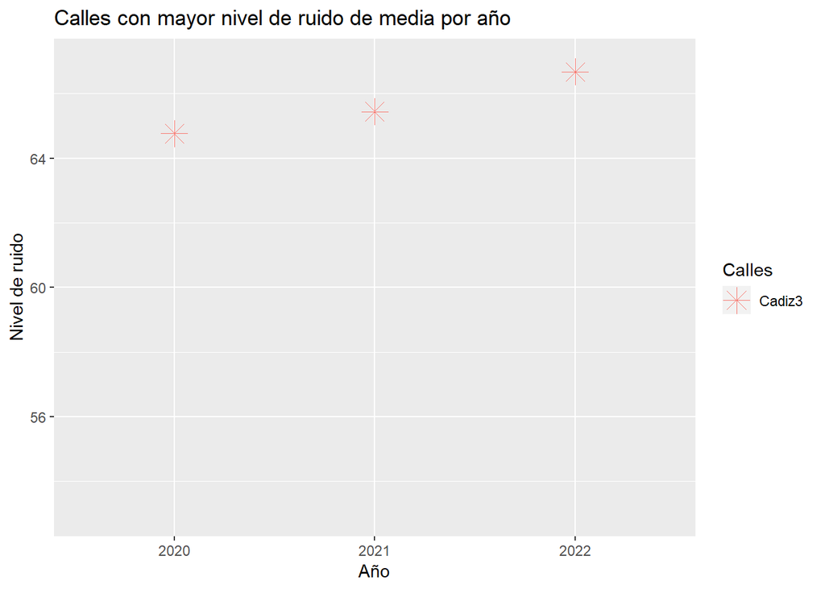

```r
a =ggplot(MaxMolestia, aes(Año, MaxRuido, color = Calles, size = MaxRuido)) + geom_point(shape = 8, size=5) + ggtitle("Calles con mayor nivel de ruido de media por año")+scale_y_continuous(limits = c(53,67),name = "Nivel de ruido")
a
```

Como podemos ver, la calle que más ha molestado a los vecinos en 2020, 2021 y 2022 es la misma, Cádiz3. Con la difrerencia que en 2022 ha habido más ruido en esa calle que en las otras dos.

· *LA QUE MENOS:*

Seguimos los mismos pasos que en el anterior.

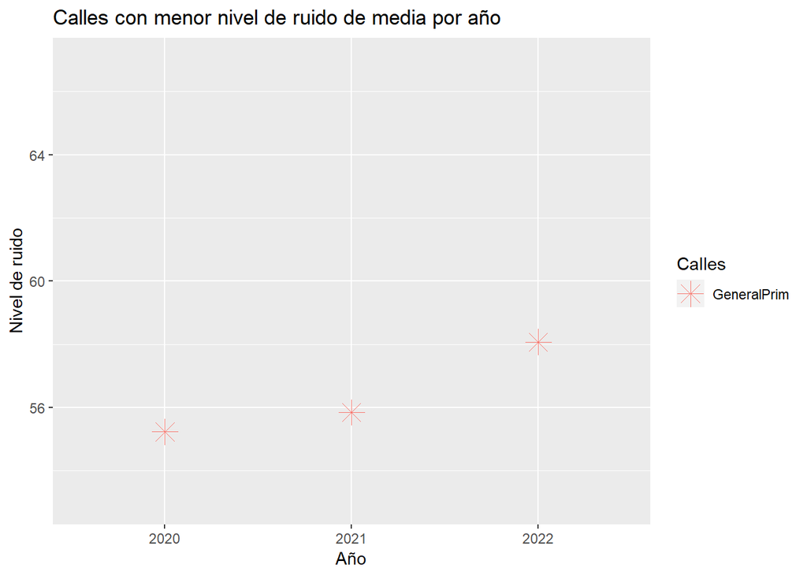

```r
Año2020 = RUZAFA_TIDY%>% group_by(Calles) %>% filter(year(Dia_Medicion) == "2020" & Nivel_Sonoro == "Nivel_Sonoro_Continuo") %>% summarise(MinRuido = mean(Valores)) %>% filter(MinRuido == min(MinRuido))

Año2021 = RUZAFA_TIDY%>% group_by(Calles) %>% filter(year(Dia_Medicion) == "2021" & Nivel_Sonoro == "Nivel_Sonoro_Continuo") %>% summarise(MinRuido = mean(Valores)) %>% filter(MinRuido == min(MinRuido))

Año2022 =  RUZAFA_TIDY%>% group_by(Calles) %>% filter(year(Dia_Medicion) == "2022" & Nivel_Sonoro == "Nivel_Sonoro_Continuo") %>% summarise(MinRuido = mean(Valores)) %>% filter(MinRuido == min(MinRuido))

#Los unimos y creamos un nuevo data frame
MinMolestia = rbind(Año2020, Año2021, Año2022)
#Añadimos la columna de años y lo convertimos en factor
MinMolestia = MinMolestia %>% mutate(Año = c(2020, 2021, 2022)) %>% mutate(Año = as.factor(Año))

#Por último representamos las calles que menos han molestado a los vecinos en los últimos 3 años
b =ggplot(MinMolestia, aes(Año, MinRuido, color = Calles, size=MinRuido)) + geom_point(shape = 8, size = 5)+ ggtitle("Calles con menor nivel de ruido de media por año")+scale_y_continuous(limits = c(53,67),name = "Nivel de ruido")
b
```

En este caso, podemos ver que la calle que menos ha molestado a los vecinos en 2020, 2021 y 2022 es la misma, GeneralPrim. Con la difrerencia que en 2020 ha habido menos ruido en esa calle que en las otras dos.

## **Pregunta 2**

**¿Qué calle ha incrementado mas el ruido a lo largo del año 2022?**

De Ruzafa tidy seleccionamos los datos de 2022 y selecionamos las columnas que nos interesan agrupadas por calles.

```r
RUZAFA_TIDY2 = RUZAFA_TIDY %>% filter(year(Dia_Medicion) == "2022") %>% group_by(Calles)
RUZAFA_TIDY2 = RUZAFA_TIDY2%>%
              select(Calles, Valores, Dia_Medicion)
```

A continuación, representamos en un geáfico la variación del ruido de cada calle por días.

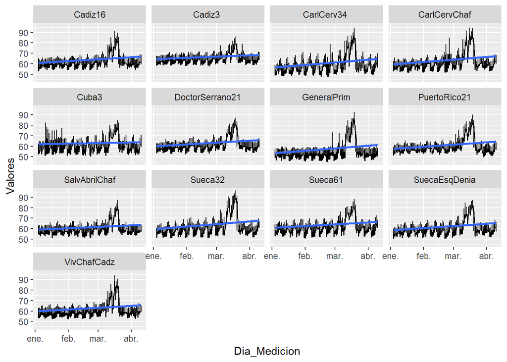

```r
ggplot(RUZAFA_TIDY2, aes(Dia_Medicion, Valores)) + geom_line() + facet_wrap(~Calles)+geom_smooth(method = 'lm')
```

Se puede ver que el nivel sonoro de cada calle a lo largo de 2022 (Enero-Abril) no varía notablemente excepto en el mes de Marzo que en todas las calles el nivel aumenta. Esto es debido a las Fallas.

Pero no sirve mucho para ver cuento aumenta o decrece el ruido Lo representamos de otra forma:

Agrupamos los datos por meses y calles. Nos quedamos solo con los valores de las calles del mes de Enero y Abril, y calculamos la media del ruido en esa calle para cada mes. Y restamos sus medias para ver cuánto ha aumentado o disminuido el nivel sonoro.

```r
#Agrupamos por meses y nos quedamos con enero y abril y calculamos sus medias por
#Calle
R1 = RUZAFA_TIDY2 %>% group_by(Mes = month(Dia_Medicion), Calles) %>% filter(Mes == 1 | Mes == 4) %>% summarise(Media= mean(Valores)) %>% mutate(Mes = as.factor(Mes))
```

[output not shown]

```r
#Ponemos los meses en columnas para poder restar sus medias
R1 = pivot_wider(R1, names_from= Mes, values_from = Media)#meses en columnas
R1 = data.frame(R1) #Convertimos los datos a data frame
R1 = R1 %>% mutate(Incremento = X4 - X1)#obtenemos el incremento por calle

R1%>%
  kbl() %>%
   kable_styling(bootstrap_options = "striped", full_width = F)
```

| Calles | X1 | X4 | Incremento |
| --- | --- | --- | --- |
| Cadiz16 | 61.43929 | 62.324 | 0.8847143 |
| Cadiz3 | 65.10000 | 65.770 | 0.6700000 |
| CarlCerv34 | 57.46714 | 59.224 | 1.7568571 |
| CarlCervChaf | 60.03929 | 61.276 | 1.2367143 |
| Cuba3 | 62.93000 | 60.904 | -2.0260000 |
| DoctorSerrano21 | 60.52286 | 61.164 | 0.6411429 |
| GeneralPrim | 54.25500 | 55.088 | 0.8330000 |
| PuertoRico21 | 58.03000 | 58.780 | 0.7500000 |
| SalvAbrilChaf | 59.47000 | 59.600 | 0.1300000 |
| Sueca32 | 60.11857 | 61.342 | 1.2234286 |
| Sueca61 | 61.50143 | 62.628 | 1.1265714 |
| SuecaEsqDenia | 59.25857 | 60.584 | 1.3254286 |
| VivChafCadz | 60.46286 | 61.154 | 0.6911429 |

```r
#mayor aumento coincide con la mas ruidosa
```

Y por último, lo representamos en un gráfico para verlo mejor:

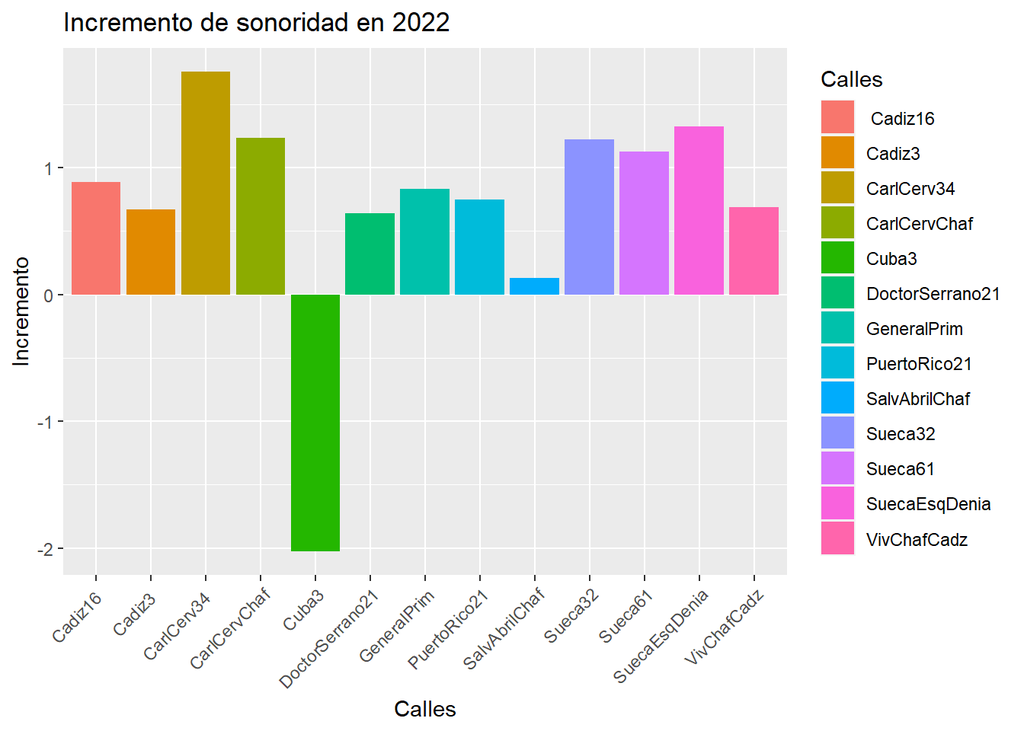

```r
ggplot(R1, aes(Calles, Incremento, fill = Calles))+ geom_col()+theme(axis.text.x = element_text(angle = 45, hjust = 1))+ ggtitle("Incremento de sonoridad en 2022")
```

Vemos que todas las calles han incrementado en el año 2022 excepto Cuba3 que su contaminacion sonora ha disminuido notoriamente. La que menos a aumentado ha sido Salvador Abril Chaflan y la que mas Carles Cervera 34

## **Pregunta 3**

**¿La sonoridad en Ruzafa ha ido aumentado o disminuyendo a lo largo del tiempo?¿El covid afectó en algo? ¿Y las fallas? ¿Y la Navidad?**

Hacemos tres graficos, para el primero seleccionamos los datos de 2020, para el segundo, los de 2021 y para el tercero los de 2022. Y representamos los datos sonoros a lo largo de cada año para ver la variacion.

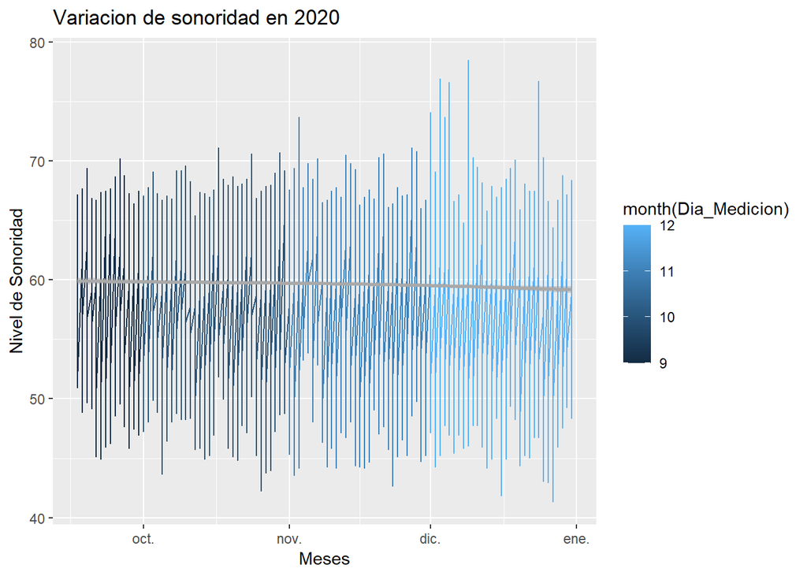

```r
#Grafico 1 (2020)
RUZAFA_TIDY3_1 = RUZAFA_TIDY %>% select(Dia_Medicion, Calles, Valores) %>% filter(year(Dia_Medicion) == "2020")
#Representacion:
ggplot(RUZAFA_TIDY3_1, aes(Dia_Medicion, Valores, color = month(Dia_Medicion)))+ geom_line() + geom_smooth(color="darkgrey")+ labs(title = "Variacion de sonoridad en 2020")+xlab("Meses") + ylab("Nivel de Sonoridad")
```

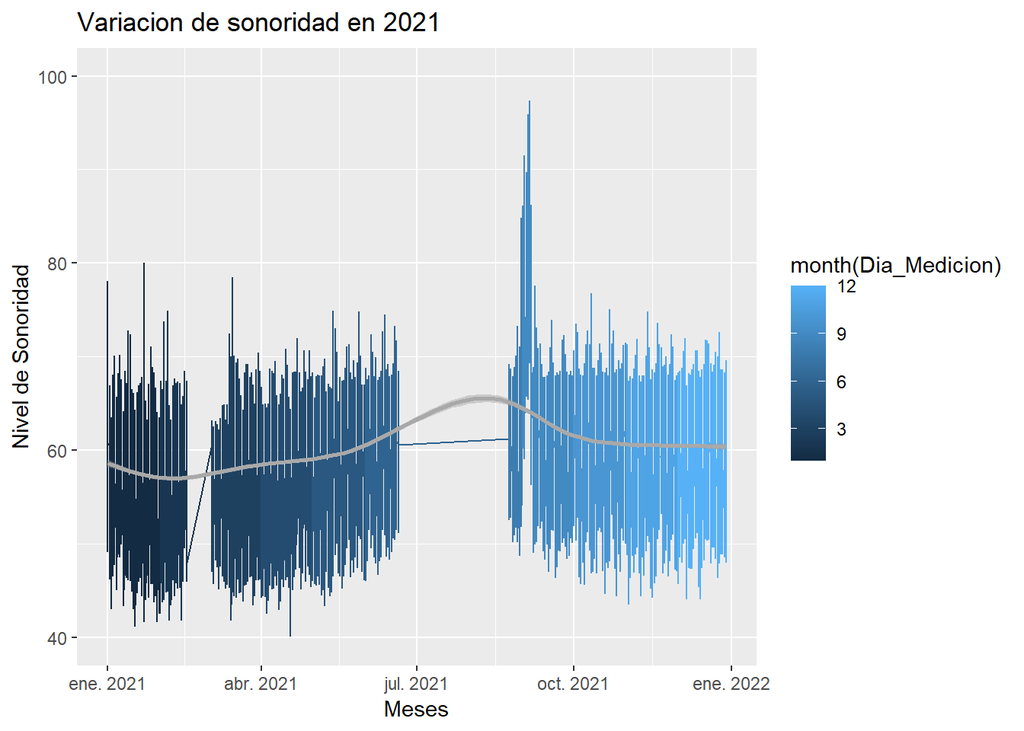

```r
#Grafico 2 (2021)
RUZAFA_TIDY3_2 = RUZAFA_TIDY %>% select(Dia_Medicion, Calles, Valores) %>% group_by(year(Dia_Medicion)) %>% filter(year(Dia_Medicion) == "2021")
#Representacion:
ggplot(RUZAFA_TIDY3_2, aes(Dia_Medicion, Valores, color = month(Dia_Medicion)))+ geom_line() + scale_y_continuous(limits=c(40,100)) + geom_smooth(color="darkgrey")+labs(title = "Variacion de sonoridad en 2021")+xlab("Meses") +ylab("Nivel de Sonoridad")
```

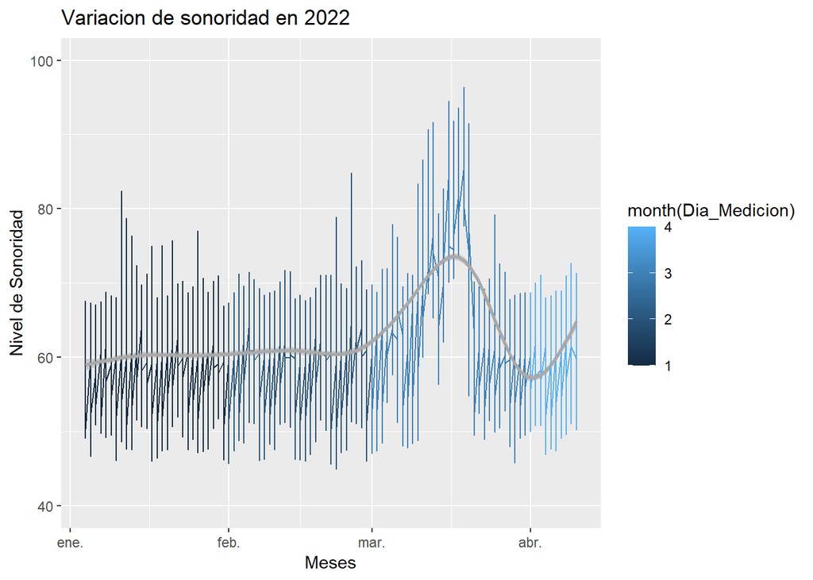

```r
#Grafico 3 (2022)
RUZAFA_TIDY3_3 = RUZAFA_TIDY %>% select(Dia_Medicion, Calles, Valores) %>% group_by(year(Dia_Medicion)) %>% filter(year(Dia_Medicion) == "2022")
#Representacion:
ggplot(RUZAFA_TIDY3_3, aes(Dia_Medicion, Valores, color = month(Dia_Medicion)))+ geom_line() + scale_y_continuous(limits=c(40,100)) + geom_smooth(color="darkgrey")+labs(title = "Variacion de sonoridad en 2022")+xlab("Meses") +ylab("Nivel de Sonoridad")
```

Se puede ver que los primeros niveles sonoros registrados fueron entorno a 60 y los ultimos registrado tambien, entonces se puede concluir que la sonoridad de Ruzafa se ha mantenido mas o menos igual.

Si que es verdad que en 2021 y 2020 los valores sonores son mucho más variados que en 2020 y por lo tanto si calculamos la media de estos valores, la media de 2021 y 2022 sera mas alta. Esto es debido a que en 2020 habían muchas restricciones nocturnas debido al Covid y tampoco se celebraban las fiestas como la Navidad. Por lo tanto, debido al Covid los niveles sonoros nocturnos y diurnos son muy parecidos por lo que durante 2020, los valores sonoros no varían mucho y son bastante constantes.

También se puede ver que en 2022 en el mes de Marzo los valores sonoros ascienden notablemente debido a las Fallas y en 2021 pasa lo mismo pero no es tan exagerado, debido de nuevo al Covid y a que estas no se llegaron a celebrar.

También en el 2021 se puede apreciar un pico en Septiembre, ya que se celebraron las Fallas se celebraron en ese mes en vez de en Marzo, como suele ser.

Ademas podemos saber que mes ha alcanzado el maximo nivel de ruido para cada calle para ver que festividad tiene mayor contaminacion acustica, las falls o la navidad.

```r
dat = RUZAFA_TIDY %>% filter(Nivel_Sonoro == "Nivel_Sonoro_Continuo")

#Maximos valores de por la noche de cada calle por meses
dat= dat%>%group_by(Calles, Mes = month(Dia_Medicion)) %>% summarise(Max = max(Valores)) %>% mutate(Mes = ifelse(Mes == 1, "enero",Mes)) %>% mutate(Mes = ifelse(Mes == 2, "febrero",Mes)) %>% mutate(Mes = ifelse(Mes == 3, "marzo",Mes)) %>% mutate(Mes = ifelse(Mes == 4, "abril",Mes)) %>% mutate(Mes = ifelse(Mes == 5, "mayo",Mes)) %>% mutate(Mes = ifelse(Mes == 6, "junio",Mes)) %>% mutate(Mes = ifelse(Mes == 7, "julio",Mes)) %>% mutate(Mes = ifelse(Mes == 8, "agosto",Mes)) %>% mutate(Mes = ifelse(Mes == 9, "septiembre",Mes)) %>% mutate(Mes = ifelse(Mes == 10, "octubre",Mes)) %>% mutate(Mes = ifelse(Mes == 11, "noviembre",Mes)) %>% mutate(Mes = ifelse(Mes == 12, "diciembre",Mes))
#En que meses estan los maximos valores por calle(Muchos en marzo---> Fallas)
data = dat %>% filter(Max > quantile(Max, 0.90))

data%>%
  kbl() %>%
  kable_classic(full_width = F, html_font = "Cambria")%>%
  row_spec(1, bold = T, color = "white", background = "#FFD39B")%>%
  row_spec(2, bold = T, color = "white", background = "#FFD39B") %>%
  row_spec(3, bold = T, color = "white", background = "#FFD39B")%>%
  row_spec(4, bold = T, color = "white", background = "#FFD39B")%>%
  row_spec(5, bold = T, color = "white", background = "#FFD39B")%>%
  row_spec(6, bold = T, color = "white", background = "#FFD39B")%>%
  row_spec(7, bold = T, color = "white", background = "#FFD39B")%>%
  row_spec(8, bold = T, color = "white", background = "#FFD39B")%>%
  row_spec(11, bold = T, color = "white", background = "#FFD39B")%>%
  row_spec(12, bold = T, color = "white", background = "#FFD39B")%>%
  row_spec(13, bold = T, color = "white", background = "#FFD39B")%>%
  row_spec(14, bold = T, color = "white", background = "#FFD39B")
```

| Calles | Mes | Max |
| --- | --- | --- |
| Cadiz16 | marzo | 85.1 |
| Cadiz3 | marzo | 79.5 |
| CarlCerv34 | marzo | 90.8 |
| CarlCervChaf | marzo | 91.3 |
| Cuba3 | marzo | 80.6 |
| DoctorSerrano21 | marzo | 82.7 |
| GeneralPrim | marzo | 88.6 |
| PuertoRico21 | marzo | 84.5 |
| SalvAbrilChaf | septiembre | 83.3 |
| Sueca2 | junio | 71.1 |
| Sueca32 | marzo | 90.2 |
| Sueca61 | marzo | 81.3 |
| SuecaEsqDenia | marzo | 82.9 |
| VivChafCadz | marzo | 85.9 |

Vemos que en el mes de marzo se alcanzan los maximos ruidos para casi todas las calles. Entonces las fallas son la festividad con mayor contaminacion acustica

## **Pregunta 4**

**¿Qué calles han sido las más ruidosas durante el día, la tarde, y la noche? ¿Y las que menos?**

```r
#Calculamos el maximo valor de ruido para el nivel sonoro de dia
MaxDia = RUZAFA_TIDY %>% filter(Nivel_Sonoro == "Nivel_Sonoro_Dia") %>% group_by(Calles)%>% select(Calles, Valores) %>% summarise(Valores = (mean(Valores))) %>% filter(Valores == max(Valores))

#Calculamos el maximo valor de ruido para el nivel sonoro de tarde
MaxTarde = RUZAFA_TIDY %>% filter(Nivel_Sonoro == "Nivel_Sonoro_Tarde") %>% group_by(Calles)%>% select(Calles, Valores) %>% summarise(Valores = (mean(Valores))) %>% filter(Valores == max(Valores))

#Calculamos el maximo valor de ruido para el nivel sonoro de noche
MaxNoche = RUZAFA_TIDY %>% filter(Nivel_Sonoro == "Nivel_Sonoro_Noche") %>% group_by(Calles)%>% select(Calles, Valores) %>% summarise(Valores = (mean(Valores))) %>% filter(Valores == max(Valores))

#creamos la columna tiempo
Tiempo = c("Dia", "Tarde", "Noche")

#Unimos los maximos valores para crear una misma tabla y añadimos la columna tiempo
a = rbind(MaxDia,MaxTarde,MaxNoche)
a = cbind(a,Tiempo =as.factor(Tiempo))
a%>%
  kbl() %>%
  kable_styling(bootstrap_options = "striped", full_width = F)
```

| Calles | Valores | Tiempo |
| --- | --- | --- |
| Cadiz3 | 66.88382 | Dia |
| Cadiz3 | 64.66282 | Tarde |
| Cadiz3 | 59.68803 | Noche |

Se puede en la tabla que la maxima contaminacion sonora la alcanza la calle Cadiz 3 tanto por el dia por la tarde como por la noche de los tres ultimos años. Coincide con los calculos anteriores donde afirbamamos que Cadiz3 es la calle con mayor media de nivel sonoro por año, es decir la que mas ha molestado a los vecinos.

Ahora hacemos exactamente lo mismo pero esta vez calculamos el minimo para el sensor de dia, tarde y noche

```r
#minimo valor de ruido para el nivel sonoro de noche
MinDia = RUZAFA_TIDY %>% filter(Nivel_Sonoro == "Nivel_Sonoro_Dia") %>% group_by(Calles)%>% select(Calles, Valores) %>% summarise(Valores = (mean(Valores))) %>% filter(Valores == min(Valores))

#minimo valor de ruido para el nivel sonoro de noche
MinTarde = RUZAFA_TIDY %>% filter(Nivel_Sonoro == "Nivel_Sonoro_Tarde") %>% group_by(Calles)%>% select(Calles, Valores) %>% summarise(Valores = (mean(Valores))) %>% filter(Valores == min(Valores))

#minimo valor de ruido para el nivel sonoro de noche
MinNoche = RUZAFA_TIDY %>% filter(Nivel_Sonoro == "Nivel_Sonoro_Noche") %>% group_by(Calles)%>% select(Calles, Valores) %>% summarise(Valores = (mean(Valores))) %>% filter(Valores == min(Valores))

#Creamos la columna tiempo
Tiempo = c("Dia", "Tarde", "Noche")

#Ponemos todos los minimos en una misma tabla y añadimos la columna tiempo
a = rbind(MinDia,MinTarde,MinNoche)
a = cbind(a,Tiempo =as.factor(Tiempo))
a %>%
  kbl() %>%
  kable_styling(bootstrap_options = "striped", full_width = F)
```

| Calles | Valores | Tiempo |
| --- | --- | --- |
| GeneralPrim | 57.69710 | Dia |
| GeneralPrim | 54.57619 | Tarde |
| GeneralPrim | 48.58427 | Noche |

Se puede en la tabla que la minima contaminacion sonora es de la calle General Prim tanto por el dia por la tarde como por la noche de los tres ultimos años. Coincide con los calculos anteriores donde afirbamamos que General Prim es la calle con menor media de nivel sonoro por año, es decir la que menos ha molestado a los vecinos.

## **Pregunta 5**

**¿Suele haber más silencio por la tarde, noche o durante el día en Ruzafa?**

Para averiguarlo, seleccionamos los valores que han medido los niveles sonoros el dia, el de la atrde y el de la noche y los agrupamos por el nivel sonoro. A continuacion calculamos la media de los valores que ha recogido cada nivel sonorodurante los tres años.

```r
#Seleccionamos los valores que han medido los niveles sonoros
TD_AÑOS = RUZAFA_TIDY %>% select(Nivel_Sonoro, Valores) %>% filter(Nivel_Sonoro == "Nivel_Sonoro_Dia" | Nivel_Sonoro == "Nivel_Sonoro_Tarde" | Nivel_Sonoro == "Nivel_Sonoro_Noche")
#Hacemos la media
TD_AÑOS= TD_AÑOS %>% group_by(Nivel_Sonoro) %>% summarise(Valores = mean(Valores))%>%mutate(Comparacion = "Todos años")%>% mutate(Comparacion = as.factor(Comparacion))

TD_AÑOS%>%
  kbl() %>%
  kable_styling()%>%
  kable_styling(bootstrap_options = "striped", full_width = F)
```

| Nivel_Sonoro | Valores | Comparacion |
| --- | --- | --- |
| Nivel_Sonoro_Dia | 61.91780 | Todos años |
| Nivel_Sonoro_Noche | 54.69623 | Todos años |
| Nivel_Sonoro_Tarde | 60.77000 | Todos años |

Vemos que suele haber mas contaminacion acustica por el dia que por la tarde o la noche, y donde hay mas silencio por la noche.

```r
#seleccionamos los datos recogidos por los niveles sonoros que nos interesan
FALLAS = RUZAFA_TIDY %>% select(Nivel_Sonoro, Valores, Fecha_Registro) %>% filter(Nivel_Sonoro == "Nivel_Sonoro_Dia" | Nivel_Sonoro == "Nivel_Sonoro_Tarde" | Nivel_Sonoro == "Nivel_Sonoro_Noche") %>%
#seleccionamos aquellos datos del 2022 del mes de marzo del 11 al 19.
filter(year(Fecha_Registro) == 2022 & month(Fecha_Registro)== 4 & day(Fecha_Registro)>10 & day(Fecha_Registro)< 20) %>% group_by(Nivel_Sonoro) %>% summarise(Valores= mean(Valores))%>%mutate(Comparacion = "Fallas") %>% mutate(Comparacion = as.factor(Comparacion))

#Unimos  los datos de fallas de 2022 y los del resto del año
COMP =rbind(TD_AÑOS,FALLAS)
COMP %>%
  kbl() %>%
  kable_styling(bootstrap_options = "striped", full_width = F)
```

| Nivel_Sonoro | Valores | Comparacion |
| --- | --- | --- |
| Nivel_Sonoro_Dia | 61.91780 | Todos años |
| Nivel_Sonoro_Noche | 54.69623 | Todos años |
| Nivel_Sonoro_Tarde | 60.77000 | Todos años |
| Nivel_Sonoro_Dia | 59.80000 | Fallas |
| Nivel_Sonoro_Noche | 60.48462 | Fallas |
| Nivel_Sonoro_Tarde | 59.58462 | Fallas |

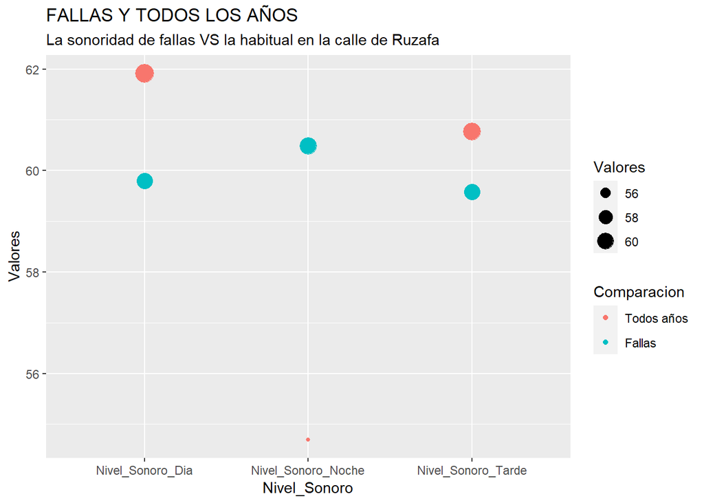

```r
#Y por ultimo lo s representamos:
ggplot(COMP, aes(Nivel_Sonoro, Valores, color= Comparacion, size = Valores)) + geom_point()+ggtitle("FALLAS Y TODOS LOS AÑOS", subtitle = "La sonoridad de fallas VS la habitual en la calle de Ruzafa")
```

## **Pregunta 6**

**¿Cuál es la calle que más MOLESTÓ a los vecinos sin contar los meses de verano? ¿Y la que menos?**

Para este caso vamos a suponer los meses de verano como: Junio, Julio y Agosto. Pero primero creamos variables de todos los meses del año en los que se ha guardado información, para así poder usar la información de forma más sencilla.

· *MÁS MOLESTIA:*

En primer lugar, seleccionamos la calle con mas ruido de cada mes, exceptuando los meses de verano que suponemos que son Junio, Julio y Agosto.

```r
ENERO = RUZAFA_TIDY %>% group_by(Calles) %>% filter(month(Dia_Medicion) == "1") %>% summarise(MaxRuido = mean(Valores)) %>% filter(MaxRuido == max(MaxRuido))

FEBRERO = RUZAFA_TIDY %>% group_by(Calles) %>% filter(month(Dia_Medicion) == "2") %>% summarise(MaxRuido = mean(Valores)) %>% filter(MaxRuido == max(MaxRuido))

MARZO = RUZAFA_TIDY %>% group_by(Calles) %>% filter(month(Dia_Medicion) == "3") %>% summarise(MaxRuido = mean(Valores)) %>% filter(MaxRuido == max(MaxRuido))

ABRIL = RUZAFA_TIDY %>% group_by(Calles) %>% filter(month(Dia_Medicion) == "4") %>% summarise(MaxRuido = mean(Valores)) %>% filter(MaxRuido == max(MaxRuido))

MAYO = RUZAFA_TIDY %>% group_by(Calles) %>% filter(month(Dia_Medicion) == "5") %>% summarise(MaxRuido = mean(Valores)) %>% filter(MaxRuido == max(MaxRuido))

SEPTIEMBRE = RUZAFA_TIDY %>% group_by(Calles) %>% filter(month(Dia_Medicion) == "9") %>% summarise(MaxRuido = mean(Valores)) %>% filter(MaxRuido == max(MaxRuido))

OCTUBRE = RUZAFA_TIDY %>% group_by(Calles) %>% filter(month(Dia_Medicion) == "10") %>% summarise(MaxRuido = mean(Valores)) %>% filter(MaxRuido == max(MaxRuido))

NOVIEMBRE = RUZAFA_TIDY %>% group_by(Calles) %>% filter(month(Dia_Medicion) == "11") %>% summarise(MaxRuido = mean(Valores)) %>% filter(MaxRuido == max(MaxRuido))

DICIEMBRE = RUZAFA_TIDY %>% group_by(Calles) %>% filter(month(Dia_Medicion) == "12") %>% summarise(MaxRuido = mean(Valores)) %>% filter(MaxRuido == max(MaxRuido))
```

Luego, los unimos y creamos un nuevo data frame para luego añadirle la columna de años convertida en Factor y añadimos la columna meses como factor.

```r
MaxMolNoVe = rbind(ENERO,FEBRERO,MARZO,ABRIL,MAYO,SEPTIEMBRE,OCTUBRE,NOVIEMBRE,DICIEMBRE)
MaxMolNoVe = MaxMolNoVe %>% mutate(Mes = c("ENERO","FEBRERO","MARZO","ABRIL","MAYO","SEPTIEMBRE","OCTUBRE","NOVIEMBRE","DICIEMBRE")) %>% mutate(Mes= as.factor(Mes))
```

Y ya, por último representamos las calles que mas han molestado a los vecinos en general exceptuando los meses de verano.

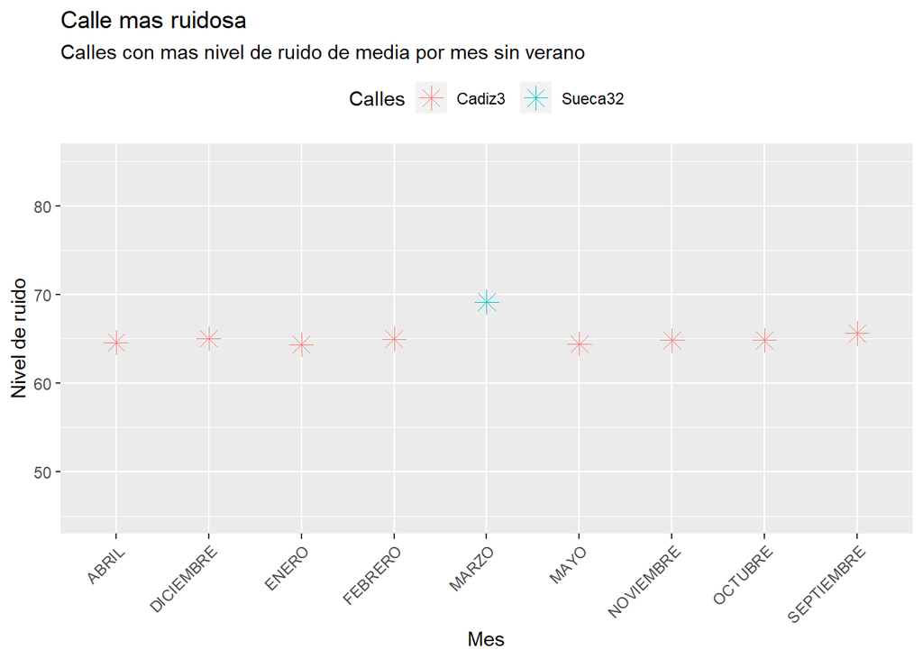

```r
maxnove =ggplot(MaxMolNoVe, aes(Mes, MaxRuido, color = Calles, size=MaxRuido)) + geom_point(shape = 8, size = 4)+ labs(title = "Calle mas ruidosa",subtitle = "Calles con mas nivel de ruido de media por mes sin verano")+scale_y_continuous(limits = c(45,85),name = "Nivel de ruido")+theme(axis.text.x = element_text(angle = 45, hjust = 1)) + theme(legend.position = "top")
maxnove
```

Observando la gráfica, podemos ver que la calle que más ha molestado a los vecinos en la mayoría de meses es Cádiz3 excepto en Marzo que fue la de Sueca32.

· *MENOS MOLESTIA:*

Realizamos los mismos pasos que en el apartado anterior, esta vez mirando los datos mínimos.

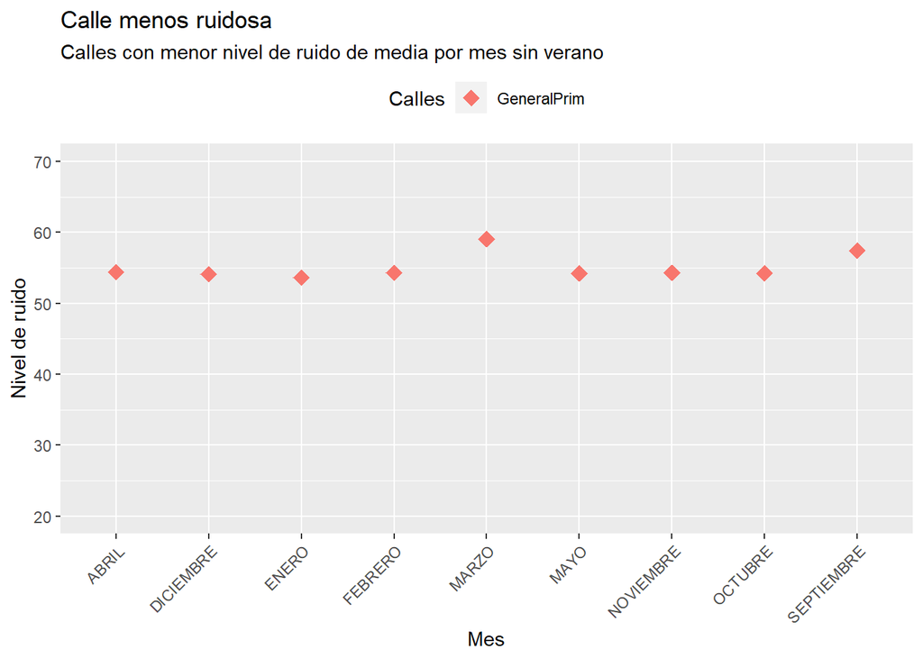

```r
ENERO2 = RUZAFA_TIDY %>% group_by(Calles) %>% filter(month(Dia_Medicion) == "1") %>% summarise(MinRuido = mean(Valores)) %>% filter(MinRuido == min(MinRuido))

FEBRERO2 = RUZAFA_TIDY %>% group_by(Calles) %>% filter(month(Dia_Medicion) == "2") %>% summarise(MinRuido = mean(Valores)) %>% filter(MinRuido == min(MinRuido))

MARZO2 = RUZAFA_TIDY %>% group_by(Calles) %>% filter(month(Dia_Medicion) == "3") %>% summarise(MinRuido = mean(Valores)) %>% filter(MinRuido == min(MinRuido))

ABRIL2 = RUZAFA_TIDY %>% group_by(Calles) %>% filter(month(Dia_Medicion) == "4") %>% summarise(MinRuido = mean(Valores)) %>% filter(MinRuido == min(MinRuido))

MAYO2 = RUZAFA_TIDY %>% group_by(Calles) %>% filter(month(Dia_Medicion) == "5") %>% summarise(MinRuido = mean(Valores)) %>% filter(MinRuido == min(MinRuido))

SEPTIEMBRE2 = RUZAFA_TIDY %>% group_by(Calles) %>% filter(month(Dia_Medicion) == "9") %>% summarise(MinRuido = mean(Valores)) %>% filter(MinRuido == min(MinRuido))

OCTUBRE2 = RUZAFA_TIDY %>% group_by(Calles) %>% filter(month(Dia_Medicion) == "10") %>% summarise(MinRuido = mean(Valores)) %>% filter(MinRuido == min(MinRuido))

NOVIEMBRE2 = RUZAFA_TIDY %>% group_by(Calles) %>% filter(month(Dia_Medicion) == "11") %>% summarise(MinRuido = mean(Valores)) %>% filter(MinRuido == min(MinRuido))

DICIEMBRE2 = RUZAFA_TIDY %>% group_by(Calles) %>% filter(month(Dia_Medicion) == "12") %>% summarise(MinRuido = mean(Valores)) %>% filter(MinRuido == min(MinRuido))

#Los unimos y creamos un nuevo data frame
MinMolNoVe = rbind(ENERO2,FEBRERO2,MARZO2,ABRIL2,MAYO2,SEPTIEMBRE2,OCTUBRE2,NOVIEMBRE2,DICIEMBRE2)
#Añadimos la columna de meses y lo convertimos en factor
MinMolNoVe = MinMolNoVe %>% mutate(Mes = c("ENERO","FEBRERO","MARZO","ABRIL","MAYO","SEPTIEMBRE","OCTUBRE","NOVIEMBRE","DICIEMBRE")) %>% mutate(Mes= as.factor(Mes))

#Por último representamos las calles que menos han molestado a los vecinos en los meses de no verano.

MinMol =ggplot(MinMolNoVe, aes(Mes, MinRuido, color = Calles, size=MinRuido)) + geom_point(shape = 8, size = 4,)+ ggtitle("Calles con menor nivel de ruido de media por mes sin verano")+scale_y_continuous(limits = c(20,70),name = "Nivel de ruido")

MinMol =ggplot(MinMolNoVe, aes(Mes, MinRuido, color = Calles, size=MinRuido)) + geom_point(shape = 18, size = 4,)+ labs(title = "Calle menos ruidosa",subtitle = "Calles con menor nivel de ruido de media por mes sin verano") +scale_y_continuous(limits = c(20,70),name = "Nivel de ruido") +theme(axis.text.x = element_text(angle = 45, hjust = 1))  + theme(legend.position = "top")

MinMol
```

Vemos que,la calle que menos ha molestado a los vecinos en todos los meses que no son verano ha sido la Calle Genral Prim. Por tanto, está será la calle más tranquila para vivir durante un año normal.

## **Pregunta 7**

**¿Qué calles son las más tranquilas para vivir en cada estación del año?**

· *VERANO:*

Suponemos verano como Agosto y Junio ya que nos faltan datos de algunos mes de Julio. Comenzamos, seleccionando los meses.

```r
JUNIO2 = RUZAFA_TIDY %>% group_by(Calles) %>% filter(month(Dia_Medicion) == "6") %>% summarise(MinRuido = mean(Valores)) %>% filter(MinRuido == min(MinRuido))

AGOSTO2 = RUZAFA_TIDY %>% group_by(Calles) %>% filter(month(Dia_Medicion) == "8") %>% summarise(MinRuido = mean(Valores)) %>% filter(MinRuido == min(MinRuido))
```

Y seguimos los mismos pasos que en la pregunta anterior para cada estación del año.

[figure not shown]

```r
#Los unimos y creamos un nuevo data frame
MinMolverano = rbind(JUNIO2,AGOSTO2)
#Añadimos la columna de años y lo convertimos en factor
MinMolverano = MinMolverano %>% mutate(Mes = c("JUNIO","AGOSTO")) %>% mutate(Mes= as.factor(Mes))
MinMolverano =ggplot(MinMolverano, aes(Mes, MinRuido, color = Calles, size=MinRuido)) + geom_point(shape = 8, size = 4,)+ labs(title = "Verano",subtitle = "Calles con mayor nivel de ruido de media en Verano") +scale_y_continuous(limits = c(20,80),name = "Nivel de ruido")
MinMolverano
```

Vemos que la calle más tranquila para el verano es General Prim. Siendo el mes de de Junio el que tiene menor contaminacion acustica.

· *OTOÑO:*

Suponemos otoño como los meses de Septiembre, Octubre, Noviembre y Diciembre.

[figure not shown]

```r
#Los unimos y creamos un nuevo data frame
MinMolOTOÑO = rbind(SEPTIEMBRE2,OCTUBRE2,NOVIEMBRE2,DICIEMBRE2)
#Añadimos la columna de años y lo convertimos en factor
MinMolOTOÑO = MinMolOTOÑO %>% mutate(Mes = c("SEPTIEMBRE","OCTUBRE","NOVIEMBRE","DICIEMBRE")) %>% mutate(Mes= as.factor(Mes))
MinMolOTOÑO =ggplot(MinMolOTOÑO, aes(Mes, MinRuido, color = Calles, size=MinRuido)) + geom_point(shape = 8, size = 4,)+labs(title = "Otoño",subtitle = "Calles con mayor nivel de ruido de media en Otoño") +scale_y_continuous(limits = c(20,80),name = "Nivel de ruido")
MinMolOTOÑO
```

La calle más tranquila para el otoño es General Prim. siedo el mes de Septiembre el que tiene mayor contaminacion acustica.

· *INVIERNO:*

Suponemos invierno como los meses de Enero, Febrero y Marzo.

[figure not shown]

```r
MinMolINV = rbind(ENERO2,FEBRERO2,MARZO2)
#Añadimos la columna de años y lo convertimos en factor
MinMolINV = MinMolINV %>% mutate(Mes = c("ENERO","FERBREO","MARZO")) %>% mutate(Mes= as.factor(Mes))
MinMolINV =ggplot(MinMolINV, aes(Mes, MinRuido, color = Calles, size=MinRuido)) + geom_point(shape = 8, size = 4,)+ labs(title = "Invierno",subtitle = "Calles con mayor nivel de ruido de media en Invierno") +scale_y_continuous(limits = c(20,80),name = "Nivel de ruido")
MinMolINV
```

La calle más tranquila para el invierno es General Prim. Siendo el mes de marzo el que tiene mas contaminacion acustica.

· *PRIMAVERA:*

Suponemos primavera como Abril y Mayo.

[figure not shown]

```r
#Los unimos y creamos un nuevo data frame
MinMolPRIM = rbind(ABRIL2,MAYO2)
#Añadimos la columna de años y lo convertimos en factor
MinMolPRIM = MinMolPRIM %>% mutate(Mes = c("ABRIL","MAYO")) %>% mutate(Mes= as.factor(Mes))
MinMolPRIM =ggplot(MinMolPRIM, aes(Mes, MinRuido, color = Calles, size=MinRuido)) + geom_point(shape = 8, size = 4,)+ labs(title = "Primavera",subtitle = "Calles con mayor nivel de ruido de media en primavera") + scale_y_continuous (limits = c(20,80),name = "Nivel de ruido")
MinMolPRIM
```

La calle más tranquila para la primavera es General Prim. Y en el mes de mayo y abril ha practicamente la misma contaminacion acustica.

En general y en concordancia con lo estudiado anteriormente, la calle más tranquila para todas las estaciones del año es la Calle General Prim.

## **Pregunta 8**

**¿Qué día de la semana hubo más ruido por calle?¿Y en general?**

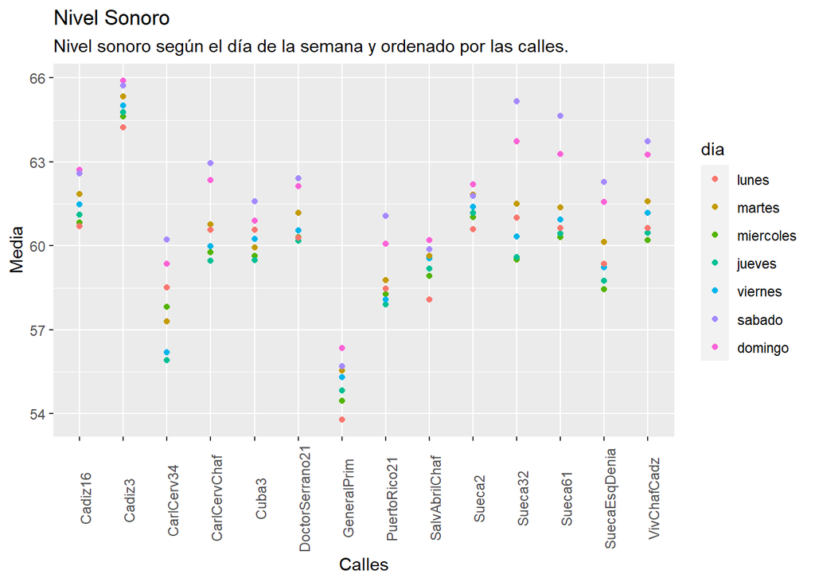

```r
ruido_calle <- RUZAFA_TIDY %>%
  mutate(dia = weekdays(Dia_Medicion))%>% # columna con los días de la semana
  mutate(dia = factor(weekdays(Dia_Medicion), ordered = F)) %>%
  select(-Dia_Medicion) %>% # eliminamos columna Dia_Medicion
  group_by(Calles,dia) %>% # agrupamos por dia y valor de ruido
  mutate(Media = mean(Valores)) %>% # columna con la media de valores
  unique() # eliminamos los valores repetidos


#Representación por puntos cada punto de cada calle sera un dia de la semana
#diferente.
ggplot(ruido_calle, aes(x = Calles, y = Media, group = dia, color = dia)) +
  geom_point() +
  theme(axis.text.x = element_text(angle = 90)) +
  labs(title = "Nivel Sonoro",
       subtitle = "Nivel sonoro según el día de la semana y ordenado por las calles.")+scale_color_discrete(labels = c("lunes","martes","miercoles","jueves","viernes","sabado","domingo"))
```

Con el gráfico que representa el nivel sonoro según el día de la semana ordenado por calles, podemos ver para cada calle, el día y el valor del nivel sonoro. Para cada día de la semana:

Sábado - Carles Cervera 34, Cuba 3, Doctor Serrano 21, Puerto Rico 21, , Sueca 32, Sueca 61, Sueca Esquina Denia

La calle menos ruidosa sigue siendo en esta representacion General Prim y la mas Cadiz3.

Ahora para visualizarlo de otra forma: Vamos a hacer otra representación para ver los niveles sonoros maximos que se han llegado a alcanzar de cada calle según el día. Esta vez, separandolo por facetas:

```r
#creamos uuna columna que contenga los dias de la semana
datos_semana <- RUZAFA_TIDY %>%
  mutate(dia = weekdays(Dia_Medicion))%>%
  mutate(dia = factor(weekdays(Dia_Medicion),ordered = T))
#Calculamos la media por dias y calles
datos_semana =  datos_semana %>% select(Calles, Valores, dia) %>% group_by(Calles,dia) %>% summarise(Media= max(Valores))
datos_semana %>%
  kbl() %>%
  scroll_box(width = "200px", height = "400px")
```

| Calles | dia | Media |
| --- | --- | --- |
| Cadiz16 | domingo | 89.3 |
| Cadiz16 | jueves | 91.5 |
| Cadiz16 | lunes | 78.3 |
| Cadiz16 | martes | 76.3 |
| Cadiz16 | miércoles | 91.2 |
| Cadiz16 | sábado | 89.7 |
| Cadiz16 | viernes | 86.4 |
| Cadiz3 | domingo | 81.3 |
| Cadiz3 | jueves | 79.9 |
| Cadiz3 | lunes | 78.5 |
| Cadiz3 | martes | 77.5 |
| Cadiz3 | miércoles | 82.0 |
| Cadiz3 | sábado | 85.8 |
| Cadiz3 | viernes | 84.1 |
| CarlCerv34 | domingo | 91.7 |
| CarlCerv34 | jueves | 83.0 |
| CarlCerv34 | lunes | 86.2 |
| CarlCerv34 | martes | 80.9 |
| CarlCerv34 | miércoles | 87.2 |
| CarlCerv34 | sábado | 95.7 |
| CarlCerv34 | viernes | 90.0 |
| CarlCervChaf | domingo | 97.4 |
| CarlCervChaf | jueves | 86.3 |
| CarlCervChaf | lunes | 81.4 |
| CarlCervChaf | martes | 82.7 |
| CarlCervChaf | miércoles | 94.5 |
| CarlCervChaf | sábado | 95.9 |
| CarlCervChaf | viernes | 91.0 |
| Cuba3 | domingo | 82.4 |
| Cuba3 | jueves | 80.6 |

[output cut: 68 more lines]

[figure not shown]

```r
#Representamos la media de cada dia de la semana por calle
ggplot(datos_semana, aes(x = dia, y = Media, color = Calles)) +
  geom_boxplot(position = "dodge") +
  scale_color_discrete(labels = c("Calle 1", "Calle 2",  "Calle 3",  "Calle 4",
                                  "Calle 5",  "Calle 6",  "Calle 7",  "Calle 8",
                                  "Calle 9",  "Calle 10",  "Calle 11",  "Calle 12",
                                  "Calle 13",  "Calle 14" )) +
  facet_wrap(~Calles) + theme(axis.text.x = element_text(angle = 90)) +
  #ordenamos los dias de la semana
  scale_x_discrete(labels = c("lunes","martes","miercoles","jueves","viernes","sabado","domingo")) + scale_y_discrete(limits = c(0,100,50)) + geom_smooth() + labs(title = "Maxima Contaminacion sonora", subtitle = "por dia de la semana en las diferentes calles")
```

```r
#LAS LINEAS ES DONDE SE SITUAN LOS MÁXIMOS
```

De esta manera fijándonos en os maximos podemos ver, dependiendo de la calle, que día ha tenido un nivel sonoro mayor y menor. Con esta tabla se puede apreciar que los maximos alcanzados por dia no teiene nada que ver para saber que calle ha sido la mas molesta o la que menos.

Y se puede ver claramente que en la calle “Carles Cervera Chaflán” hubo un nivel sonoro muy alto el domingo. Luego podemos ver que en las siguientes calles; “Carles Cervera 34”, “General Prim” y “Carles Cervera Chaflán”, el nivel sonoro el sabado era muy alto.

Ahora vamos a ver la representación del nivel sonoro durante la semana sin tener en cuenta las calles.

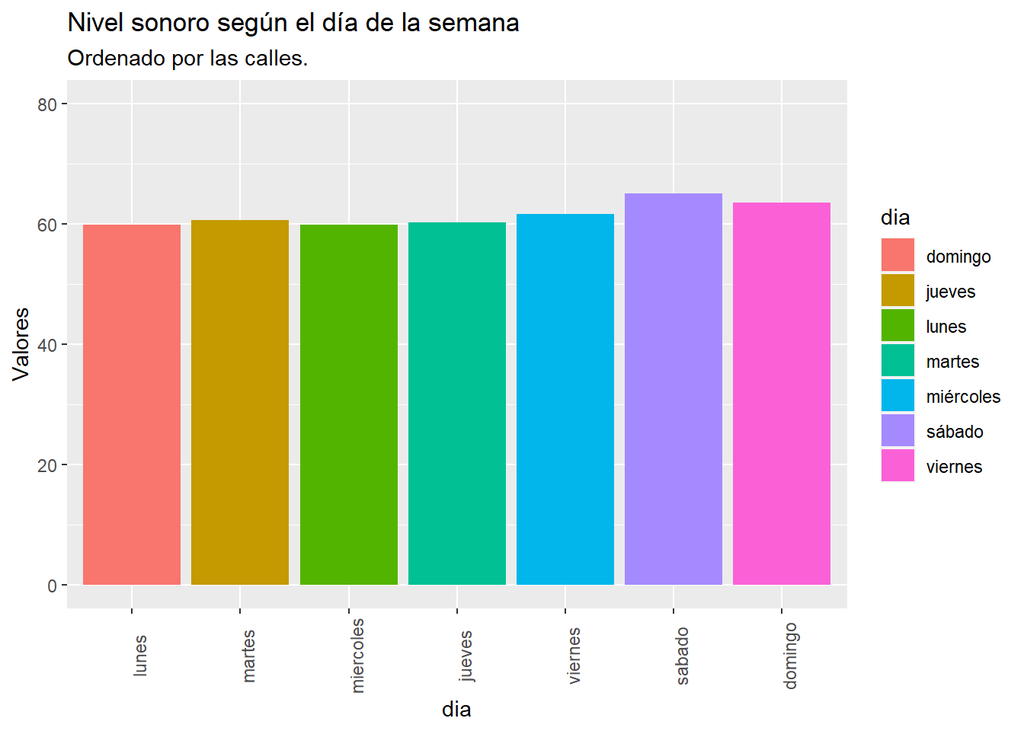

```r
ggplot(ruido_calle, aes(x = dia, y = Valores, fill = dia)) +
  geom_col(position = "stack") +
  theme(axis.text.x = element_text(angle = 90)) +
  labs(title = "Nivel sonoro según el día de la semana",
       subtitle = "Ordenado por las calles.")+ scale_y_continuous(limits = c(0,80))+
  scale_x_discrete(labels = c("lunes","martes","miercoles","jueves","viernes","sabado","domingo"))
```

Podemos ver que el día que tiene los niveles sonoros más altos es el sábado y despues el viernes, coincide con los niveles de los dias de la semana mas alto por calle que son tambien o el viernes o el sabado.

## **Análisis Univariante**

En esta sección vamos a analizar los datos variable a variable. Para ello vamos a utilizar un tidy Dataset, el dataframe $RUZAFA_TIDY$.

Primero vamos a obtener la media de las variables, aunque de algunas no vamos a obtener resultados ya que sus valores no son numéricos. Por tanto, vamos a hacer este análisis de las variables numéricas.

```r
mean(RUZAFA_TIDY$Id)
mean(RUZAFA_TIDY$Fecha_Registro)
mean(RUZAFA_TIDY$Valores)
mean(RUZAFA_TIDY$Dia_Medicion)
```

Media del número de valores que hay en el dataframe: $mean(Id)=386.3347$. Media de las fechas de registro: $mean(FechaRegistro)="2021-06-29"$, es decir, el 29 de junio de 2021. Media de los niveles de sonoridad: $mean(Valores)=60.4308$. Media deldia de medición: $mean(DiaMedicion)="2021-06-28"$, es decir, el 28 de junio de 2021.

Ahora, vamos a obtener la mediana de las variables.

```r
median(RUZAFA_TIDY$Id)
```

```
## [1] 231
```

```r
median(RUZAFA_TIDY$Fecha_Registro)
```

```
## [1] "2021-06-05"
```

```r
median(RUZAFA_TIDY$Valores)
```

```
## [1] 60.6
```

```r
median(RUZAFA_TIDY$Dia_Medicion)
```

```
## [1] "2021-06-04"
```

Mediana del número de valores que hay en el dataframe: $231$. Mediana de las fechas de registro: $"2021-06-05"$, es decir, el 5 de junio de 2021. Mediana de los niveles de sonoridad: $60.6$. Mediana del dia de medición: $"2021-06-04"$, es decir, el 4 de junio de 2021.

Vamos a hacer una tabla de frecuencia de cada variable.No vamos a hacer una tabla de frecuencia de la variable $Id$, por que al ser un identificador es único, es decir, su frecuencia es cero para todos los casos.

```r
#Variable Fecha_Registro
f_fr <-table(RUZAFA_TIDY$Fecha_Registro)
f_fr=head(f_fr)
f_fr %>%
  kbl() %>%
  kable_styling(bootstrap_options = "striped", full_width = F, position = "left")
```

| Var1 | Freq |
| --- | --- |
| 2020-09-18 | 65 |
| 2020-09-19 | 65 |
| 2020-09-20 | 65 |
| 2020-09-21 | 65 |
| 2020-09-22 | 60 |
| 2020-09-23 | 60 |

```r
#Variable Valores
f_v <- table(RUZAFA_TIDY$Valores)
f_v %>%
  kbl() %>%
  kable_styling(bootstrap_options = "striped", full_width = F, position = "left")%>%
  scroll_box(width = "200px", height = "500px")
```

| Var1 | Freq |
| --- | --- |
| 40.1 | 1 |
| 41.1 | 1 |
| 41.3 | 1 |
| 41.6 | 2 |
| 41.8 | 4 |
| 42.1 | 1 |
| 42.2 | 2 |
| 42.3 | 1 |
| 42.5 | 4 |
| 42.6 | 1 |
| 42.8 | 1 |
| 42.9 | 2 |
| 43 | 3 |
| 43.3 | 2 |
| 43.4 | 3 |
| 43.5 | 3 |
| 43.6 | 4 |
| 43.7 | 3 |
| 43.8 | 4 |
| 43.9 | 3 |
| 44 | 4 |
| 44.1 | 9 |
| 44.2 | 9 |
| 44.3 | 5 |
| 44.4 | 11 |
| 44.5 | 4 |
| 44.6 | 4 |
| 44.7 | 5 |
| 44.8 | 6 |
| 44.9 | 9 |

[output cut: 468 more lines]

```r
#Variable Dia_Medicion
f_dm <- table(RUZAFA_TIDY$Dia_Medicion)
f_dm %>%
  kbl() %>%
  kable_styling(bootstrap_options = "striped", full_width = F, position = "left")%>%
   scroll_box(width = "200px", height = "500px")
```

| Var1 | Freq |
| --- | --- |
| 2020-09-17 | 65 |
| 2020-09-18 | 65 |
| 2020-09-19 | 65 |
| 2020-09-20 | 65 |
| 2020-09-21 | 60 |
| 2020-09-22 | 60 |
| 2020-09-23 | 55 |
| 2020-09-24 | 55 |
| 2020-09-25 | 55 |
| 2020-09-26 | 55 |
| 2020-09-27 | 45 |
| 2020-09-28 | 50 |
| 2020-09-29 | 55 |
| 2020-09-30 | 55 |
| 2020-10-01 | 55 |
| 2020-10-02 | 55 |
| 2020-10-03 | 55 |
| 2020-10-04 | 55 |
| 2020-10-05 | 55 |
| 2020-10-06 | 55 |
| 2020-10-07 | 55 |
| 2020-10-08 | 55 |
| 2020-10-09 | 55 |
| 2020-10-10 | 55 |
| 2020-10-11 | 55 |
| 2020-10-12 | 55 |
| 2020-10-13 | 65 |
| 2020-10-14 | 65 |
| 2020-10-15 | 70 |
| 2020-10-16 | 70 |

[output cut: 458 more lines]

Vamos a hacer una representación de la densidad de los valores sonoros, para ver cual es el nivel sonoro que más ocurre y el que menos.

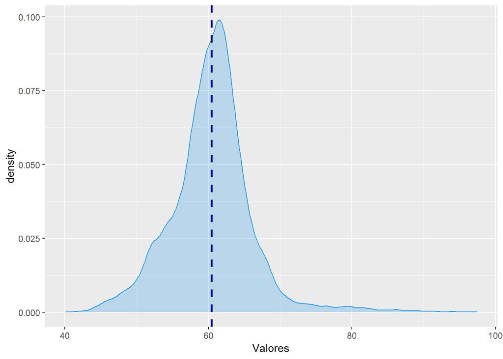

```r
RUZAFA_TIDY5 = RUZAFA_TIDY%>%filter(Nivel_Sonoro == "Nivel_Sonoro_Dia" |Nivel_Sonoro == "Nivel_Sonoro_Noche" | Nivel_Sonoro == "Nivel_Sonoro_Tarde" )

ggplot(RUZAFA_TIDY, aes(Valores))+geom_density()+geom_density(color = 4,
               fill = 4,
               alpha = 0.25)+geom_vline(xintercept = mean(RUZAFA_TIDY$Valores), na.rm = T, color = "darkblue", linetype = "dashed", lwd = 1)
```

En esta representación vemos claramente que la densidad del nivel sonoro entre $55$ y $65$ es la que más destaca, por tanto, sabemos que el nivel sonoro que más ocurre en nuestros datos está entre el $55$ y $65$.

Al compararlo con la media vemos que casi coincide con el valor mas habitual.

Y si calculamos la densidad de los valores registrados por el nivel dia, el de la tarde y el de la noche. Vemos que coincide con las deduciiones anteriores. La mayor contaminacion acustica sucede por el dia y la menor por la noche.

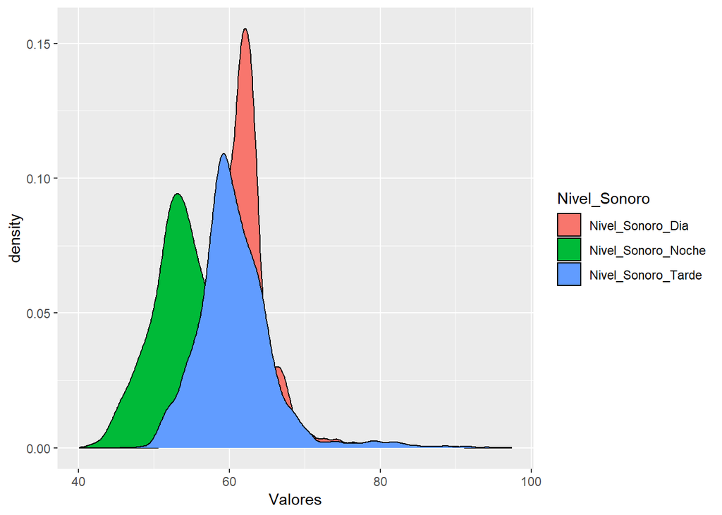

```r
ggplot(RUZAFA_TIDY5, aes(Valores, fill = Nivel_Sonoro ))+geom_density()
```

## **Análisis Bivariante**

Matriz de covarianza de todos los niveles sonoros para ver cuales tienen mas relación entre sí

```r
#Usamos pivot wider poner de nuevo en columnas los niveles sonoros y poder ver el
#nivel de relacion entre  las variables

a = pivot_wider(RUZAFA_TIDY,names_from = "Nivel_Sonoro", values_from = "Valores" )
#Seleccionamos aquellas columnas que empiezen por Nivel
Datos <- select(a, starts_with("Nivel"))

#Usamos le metodod de pearson para estudiar las relaciones
b = cor(Datos, method="pearson")
#Cambiamos el nombre las filas y columnas
colnames(b) <- c("Continuo", "Dia", "d,t,n", "Tarde", "Noche")
rownames(b) <- c("Continuo", "Dia", "d,t,n", "Tarde", "Noche")
b%>%
  kbl() %>%
  kable_paper("hover")
```

|  | Continuo | Dia | d,t,n | Tarde | Noche |
| --- | --- | --- | --- | --- | --- |
| Continuo | 1.0000000 | 0.9547164 | 0.9430505 | 0.8200068 | 0.7838474 |
| Dia | 0.9547164 | 1.0000000 | 0.8197269 | 0.7336498 | 0.6225116 |
| d,t,n | 0.9430505 | 0.8197269 | 1.0000000 | 0.8464457 | 0.9349781 |
| Tarde | 0.8200068 | 0.7336498 | 0.8464457 | 1.0000000 | 0.7765522 |
| Noche | 0.7838474 | 0.6225116 | 0.9349781 | 0.7765522 | 1.0000000 |

[figure not shown]

```r
ggcorr(b, palette = "Pastel 2 ", color = 1:5, label = T, method = c("everything", "pearson"))
```

Ahora estudiamos el grado de relacion de los siguientes valores que son los que hemos usadoo mayoritariamente en este analisis de Ruzafa

```r
cat("Relacion Dia y Noche")
cor(a$Nivel_Sonoro_Noche,a$Nivel_Sonoro_Dia, method = "pearson")
cat("Relacion Dia y Tarde")
cor(a$Nivel_Sonoro_Tarde, a$Nivel_Sonoro_Dia, method = "pearson")
cat("Relacion Tarde y Noche")
cor(a$Nivel_Sonoro_Tarde, a$Nivel_Sonoro_Noche, method = "pearson")
```

Relacion Dia y Noche = 0.622 Relacion Dia y Tarde = 0.733 Relacion Tarde y Noche = 0.776

Vemos que los valores de la Tarde y la Noche son los mas relacionados

```r
#Vemos que el continuo tiene mas relacion con los valores de sonido de por el
#dia, y el que menos por la noche
cor(a$Nivel_Sonoro_Continuo, a$Nivel_Sonoro_Dia, method= "pearson")
cor(a$Nivel_Sonoro_Continuo, a$Nivel_Sonoro_Noche, method= "pearson")
cor(a$Nivel_Sonoro_Continuo, a$Nivel_Sonoro_Tarde, method= "pearson")
```

Relacion Continuo y Dia = 0.954 Relacion Continuo y Noche = 0.783 Relacion Continuo y Tarde = 0.820

CONCLUSIóN : A los estudiantes les recomendamos la calle General Prim para vivir ya que es la que menos contamiacion acustica tiene, y la que menos les recomendariamos seria Cadiz3.